# Analysis of Kent County property data by subdivision

In this excercise, I take subdivision level property data and try to answer the following questions:

1. In which subdivisions are houses selling the fastest? Selling slowest?
2. In which subdivisions is the median sale price improving most? Dropping most?
3. Where can a seller get the best deal in terms of sale price / original listing price?

## Methodology

To tackle these questions, I'm using [Pandas](http://pandas.pydata.org/) - a Python library for data analysis - and [SciPy](http://docs.scipy.org/doc/scipy-0.13.0/reference/index.html) - a mathematics, science and engineering library - to filter, group and ultimately run a [ordinary least squares linear regression](http://en.wikipedia.org/wiki/Ordinary_least_squares) to determine the positive or negative movement on a number of variables.

## About the data

The subdivision level data comes from Trend MLS, a real estate data company that provides research for realtors in New Castle and Kent counties. Trend was only able to provide us with subdivision- and Zip code-level data for 2010-2013, inclusive. Because of the large size of Zip codes, we'll focus exclusively on subdivisions. The basic structure of the .csv data is:

- Subdivision
  - The name of the subdivision
- Year
  - The data year
- Sales
  - Number of transactions
  - (Note this doesn't necessarily mean number of homes)
- Median Sale Price
  - Median price of transactions
- Avg. Sale Price
  - Average price of transactions
- Median Days on Market
  - Median number of days the house was listed for sale.
- Avg. Days on Market
  - Average number of days the house was listed for sale.
- Median Sale Price / Original Listing Price
  - The ratio between sale price and the original listing price
  - A value above 1.0 means the homes sold for more than the original listing price.
- Median Sale Price / Listing Price
  - The ratio between the sale price and last listing price.
  - Again, a value above 1.0 means the homes sold for more than the listing price.

## Known Issues

There are two issues that directly affect this analysis:

1. Not all subdivisions have data for every year.
   - This could simply be missing data or zero (0) homes were sold in that subdivision for that year.
   - WORKAROUND: In this excercise, we are ommitting all subdivisions that don't have data for at least three years.
2. In many subdivisions, there is a very small number of sales.
   - This means we are analyzing medians and trying to find trends in some areas where the number of transactions is very small.
   - WORKAROUND: For this excercise, we limit the subdivisions/year combos to only those that have at least 5 transactions.

## Preparing the data

```python
# General Imports
import matplotlib.pyplot as plt
import pandas as pd
import re
from scipy.stats import linregress
# Enable inline plotting
%matplotlib inline
```

```python
# import the data into a Pandas dataframe.
df = pd.read_csv('Kent Home Sales.csv')
print "Original Data:"
print df.info()
print "="*100

# Filter out data where the subdivision is "None Available."
df = df[df.Subdiv != 'None Available']

# Get the total number of subdivisions
orig_subdiv_count = len(df.Subdiv.unique())

# Filter out data where there are less than 5 sales
df = df[df.Sales >= 5]

# Filter out the subdivisions that don't have 4 years
# worth of data.
df = df.groupby('Subdiv').filter(lambda x: x.count() >= 3)

# Get the number of subdivisions that survived the cuts
new_subdiv_count = len(df.Subdiv.unique())

# R-SQUARED THRESHOLD
R2_THRESHOLD = 0.5

# Set the Subdivision as the Index.
df = df.set_index(['Subdiv'])
print "Filtered Data:"
df.info()

# Group by the subdivisions for use in our calculations below
by_subdivision = df.groupby(df.index)
```

```
Original Data:
<class 'pandas.core.frame.DataFrame'>
Int64Index: 1243 entries, 0 to 1242
Data columns (total 9 columns):
Subdiv               1243 non-null object
Year                 1243 non-null int64
Sales                1243 non-null int64
Median Sold Price    1243 non-null float64
Avg.SP               1243 non-null float64
Median DOM           1243 non-null float64
Avg.DOM              1243 non-null float64
Median.SP.OLP        1243 non-null float64
Median.SP.LP         1243 non-null float64
dtypes: float64(6), int64(2), object(1)None
====================================================================================================
Filtered Data:
<class 'pandas.core.frame.DataFrame'>
Index: 190 entries, Bicentennial Vil to Wynsome Knoll
Data columns (total 8 columns):
Year                 190 non-null int64
Sales                190 non-null int64
Median Sold Price    190 non-null float64
Avg.SP               190 non-null float64
Median DOM           190 non-null float64
Avg.DOM              190 non-null float64
Median.SP.OLP        190 non-null float64
Median.SP.LP         190 non-null float64
dtypes: float64(6), int64(2)
```

```python
print "Examining %d of %d subdivisions (%.2f percent)" % (new_subdiv_count, orig_subdiv_count, ( float(new_subdiv_count) / orig_subdiv_count * 100 ))
```

```
Examining 54 of 436 subdivisions (12.39 percent)
```

```python
# Integrity Check: Top # of property sales.
# This should be Trolley Square
most_sales = df.sort(['Sales'], ascending=[0])
print "**Subdivisions with the most sales:"
most_sales.head(5)[['Year', 'Sales']]
```

```
**Subdivisions with the most sales:
```

| Subdiv | Year | Sales |
| --- | --- | --- |
| Village Of Westove | 2013 | 26 |
| Garrison Lake Gree | 2012 | 22 |
| Whitetail Run | 2010 | 21 |
| Harrington | 2013 | 21 |
| Lakeshore Village | 2012 | 21 |

5 rows × 2 columns

```python
# Integrity Check: There should be 7 subdivisions,year combos with a Median DOM
# of only 1 day.
shortest_dom = df.sort(['Median DOM'], ascending=[1])
print "**Subdivisions with the shortest median DOM:"
shortest_dom.head(7)[['Year', 'Median DOM', 'Sales']]
```

```
**Subdivisions with the shortest median DOM:
```

| Subdiv | Year | Median DOM | Sales |
| --- | --- | --- | --- |
| Whitetail Run | 2011 | 1.0 | 15 |
| Pinehurst Village | 2010 | 1.0 | 15 |
| Emerald Pointe | 2011 | 1.5 | 6 |
| Whitetail Run | 2012 | 7.0 | 10 |
| Wicksfield | 2012 | 7.5 | 8 |
| Newells Creek | 2013 | 14.0 | 6 |
| Whitetail Run | 2010 | 14.0 | 21 |

7 rows × 3 columns

### Examining issues with number of sales

As the histograms below show, a large portion of our data is made up of subdivisions with only a few sales in an entire year.

```
The most popular Subdivision/Year:
```

| Subdiv | Year | Sales | Median Sold Price | Avg.SP | Median DOM | Avg.DOM | Median.SP.OLP | Median.SP.LP |
| --- | --- | --- | --- | --- | --- | --- | --- | --- |
| Village Of Westove | 2013 | 26 | 109500 | 115942.2308 | 24.5 | 67.346154 | 1 | 1 |

1 rows × 8 columns

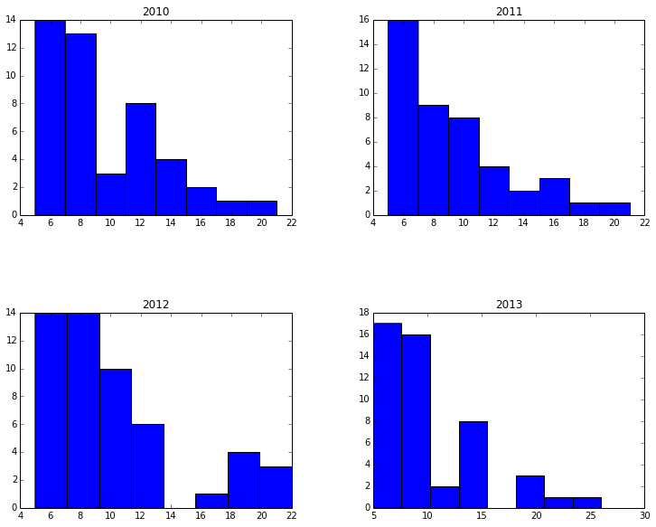

```python
# Plot Subdivisions by number of sales.
df['Sales'].hist(by=df.Year, bins=8, figsize=(12,10))
print "The most popular Subdivision/Year:"
df[df['Sales'] == df['Sales'].max()]
```

### How does DOM compare to other factors?

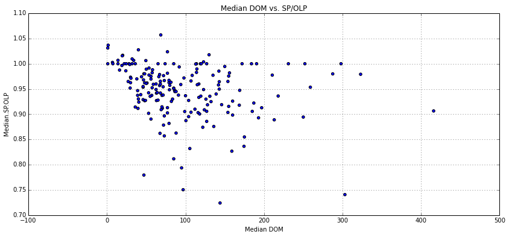

```python
df.plot(
    x="Median DOM",
    y="Median.SP.OLP",
    kind='scatter',
    title="Median DOM vs. SP/OLP",
    figsize=[14,6])
```

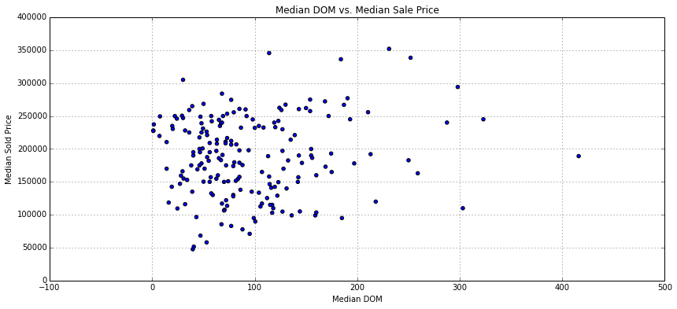

```python
df.plot(
    x="Median DOM",
    y="Median Sold Price",
    kind='scatter',
    title="Median DOM vs. Median Sale Price",
    figsize=[14,6])
```

```
Median DOM by year:
```

```
array([[<matplotlib.axes.AxesSubplot object at 0x118f9ec10>,
        <matplotlib.axes.AxesSubplot object at 0x118eeacd0>]], dtype=object)
```

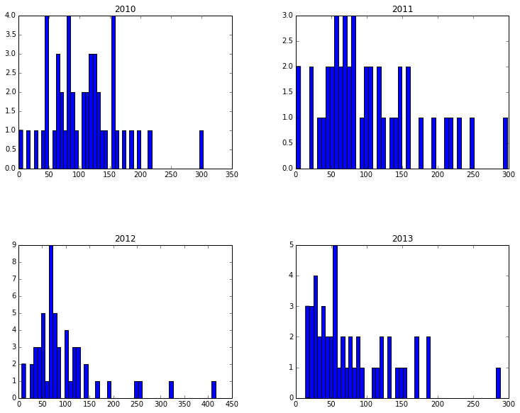

```python
print "Median DOM by year:"
df['Median DOM'].hist(by=df.Year, figsize=[12,10])
```

```
SP/OLP by year
```

```
array([[<matplotlib.axes.AxesSubplot object at 0x118efa450>,
        <matplotlib.axes.AxesSubplot object at 0x11951a550>]], dtype=object)
```

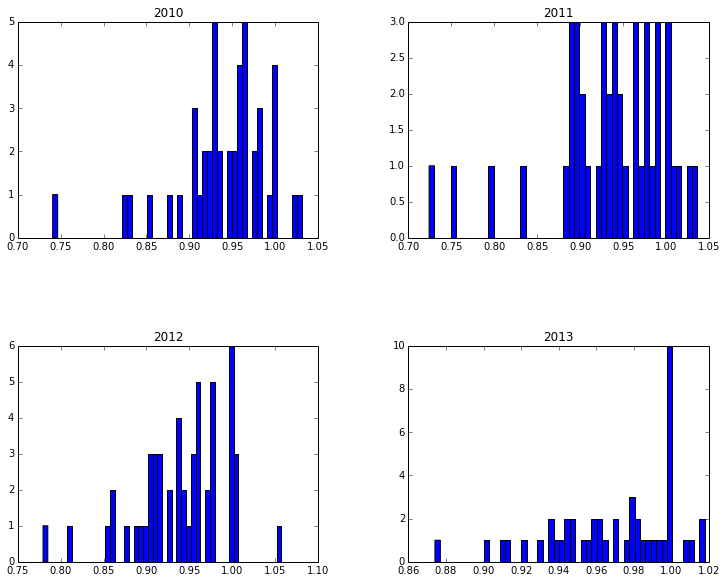

```python
print "SP/OLP by year"
df['Median.SP.OLP'].hist(by=df.Year, figsize=[12,10])
```

```
SP/OLP For All Years
```

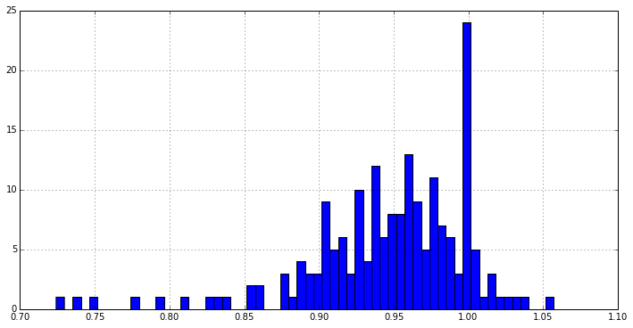

```python
print "SP/OLP For All Years"
df['Median.SP.OLP'].hist(bins=60, figsize=[12,6])
```

# 1. In which subdivisions are houses selling the fastest? Selling slowest?

Grouping our data by subdivision, we are able to run each through a linear regression with SciPy's `linregress` function.

Back to top

```python
def calculateSlope(df, attribute, r_squared_threshold=R2_THRESHOLD):
    """Gets the slope of an attribute of the dataframe along with
    min, max and r-squared values."""
    # Using scipy's linregress, get the slope of dom/year for each subdivision
    slope = pd.DataFrame(df.apply(lambda x: linregress(y=x[attribute], x=x.Year)[0]))
    r2 = pd.DataFrame(df.apply(lambda x: linregress(y=x[attribute], x=x.Year)[2]**2))
    output = pd.merge(left=slope, right=r2, left_index=True, right_index=True)

    # Get the max and min DOM for each subdivision.
    output = pd.merge(left=output, right=pd.DataFrame(df[attribute].min()), left_index=True, right_index=True)
    output = pd.merge(left=output, right=pd.DataFrame(df[attribute].max()), left_index=True, right_index=True)
    output= pd.merge(left=output, right=pd.DataFrame(df['Sales'].sum()), left_index=True, right_index=True)

    # Fix Column names
    attribute = re.sub(r'[\W]+', '_', attribute).lower()
    output.columns = [attribute+'_slope', attribute+'_r2', attribute+'_min', attribute+'_max', 'sales_count']

    return output, output[output[attribute+'_r2'] >= r_squared_threshold]
```

```
array([[<matplotlib.axes.AxesSubplot object at 0x1196d1610>,
        <matplotlib.axes.AxesSubplot object at 0x1198ff190>]], dtype=object)
```

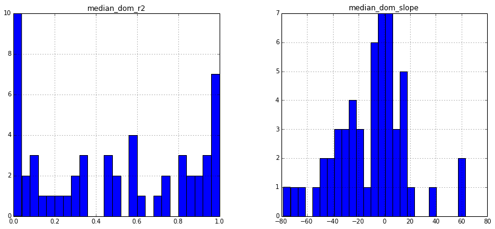

```python
median_dom, median_dom_adj = calculateSlope(by_subdivision, 'Median DOM')
median_dom[['median_dom_slope', 'median_dom_r2']].hist(bins=25, figsize=[14,6])
```

```python
print "The best fit:"
median_dom[median_dom.median_dom_r2 == median_dom.median_dom_r2.max()]
```

```
The best fit:
```

| Subdiv | median_dom_slope | median_dom_r2 | median_dom_min | median_dom_max | sales_count |
| --- | --- | --- | --- | --- | --- |
| The Orchards | -43.785714 | 0.999354 | 22 | 154 | 15 |

1 rows × 5 columns

```python
print "The Worst fit:"
median_dom[median_dom.median_dom_r2 == median_dom.median_dom_r2.min()]
```

```
The Worst fit:
```

| Subdiv | median_dom_slope | median_dom_r2 | median_dom_min | median_dom_max | sales_count |
| --- | --- | --- | --- | --- | --- |
| Chestnut Ridge | 0.3 | 0.000048 | 24 | 143 | 30 |

1 rows × 5 columns

### The top and bottom five for DOM

```python
print "TOP 5:"
median_dom.sort(['median_dom_slope']).head(5)
```

```
TOP 5:
```

| Subdiv | median_dom_slope | median_dom_r2 | median_dom_min | median_dom_max | sales_count |
| --- | --- | --- | --- | --- | --- |
| Brenford Woods | -78.50 | 0.988755 | 36.0 | 193 | 21 |
| Towne Point | -72.00 | 0.955224 | 16.0 | 160 | 21 |
| Stoney Creek | -64.50 | 0.750000 | 88.0 | 303 | 20 |
| Cannon Mills | -51.50 | 0.595610 | 50.0 | 175 | 20 |
| Persimmon Park Pl | -48.25 | 0.992530 | 39.5 | 136 | 21 |

5 rows × 5 columns

```python
print "TOP 5 (adjusted for better R^2 values):"
median_dom_adj.sort(['median_dom_slope']).head(5)
```

```
TOP 5 (adjusted for better R^2 values):
```

| Subdiv | median_dom_slope | median_dom_r2 | median_dom_min | median_dom_max | sales_count |
| --- | --- | --- | --- | --- | --- |
| Brenford Woods | -78.50 | 0.988755 | 36.0 | 193 | 21 |
| Towne Point | -72.00 | 0.955224 | 16.0 | 160 | 21 |
| Stoney Creek | -64.50 | 0.750000 | 88.0 | 303 | 20 |
| Cannon Mills | -51.50 | 0.595610 | 50.0 | 175 | 20 |
| Persimmon Park Pl | -48.25 | 0.992530 | 39.5 | 136 | 21 |

5 rows × 5 columns

```python
print "Bottom 5:"
median_dom.sort(['median_dom_slope'], ascending=False).head(5)
```

```
Bottom 5:
```

| Subdiv | median_dom_slope | median_dom_r2 | median_dom_min | median_dom_max | sales_count |
| --- | --- | --- | --- | --- | --- |
| Emerald Pointe | 62.700000 | 0.474126 | 1.5 | 287.5 | 36 |
| Wynsome Knoll | 58.000000 | 0.920614 | 40.0 | 156.0 | 22 |
| Hidden Pond | 35.750000 | 0.832750 | 71.5 | 143.0 | 27 |
| Willowwood | 20.928571 | 0.088468 | 126.0 | 323.0 | 27 |
| Laureltowne | 17.500000 | 0.223486 | 30.0 | 104.0 | 25 |

5 rows × 5 columns

```python
print "Bottom 5 (adjusted for better R^2 values):"
median_dom_adj.sort(['median_dom_slope'], ascending=False).head(5)
```

```
Bottom 5 (adjusted for better R^2 values):
```

| Subdiv | median_dom_slope | median_dom_r2 | median_dom_min | median_dom_max | sales_count |
| --- | --- | --- | --- | --- | --- |
| Wynsome Knoll | 58.00 | 0.920614 | 40.0 | 156.0 | 22 |
| Hidden Pond | 35.75 | 0.832750 | 71.5 | 143.0 | 27 |
| Providence Crossing | 16.40 | 0.565517 | 68.0 | 127.0 | 52 |
| Twin Willows | 15.25 | 0.811029 | 46.5 | 77.0 | 20 |
| Foxhall | 14.25 | 0.975617 | 46.0 | 86.5 | 28 |

5 rows × 5 columns

### Close look at top and bottom DOM subdivisions

#### The top subdivisions (both normal and R^2 corrected)

```python
df[df.index == median_dom[median_dom.median_dom_slope == median_dom.median_dom_slope.min()].index]
```

| Subdiv | Year | Sales | Median Sold Price | Avg.SP | Median DOM | Avg.DOM | Median.SP.OLP | Median.SP.LP |
| --- | --- | --- | --- | --- | --- | --- | --- | --- |
| Brenford Woods | 2011 | 7 | 245000 | 239231.2857 | 193 | 309.714286 | 0.892889 | 0.950000 |
| Brenford Woods | 2012 | 9 | 232000 | 238959.6667 | 100 | 107.222222 | 0.936670 | 0.981818 |
| Brenford Woods | 2013 | 5 | 259102 | 256281.2000 | 36 | 120.400000 | 1.000009 | 1.000009 |

3 rows × 8 columns

```python
df[df.index == median_dom[median_dom.median_dom_slope == median_dom_adj.median_dom_slope.min()].index]
```

| Subdiv | Year | Sales | Median Sold Price | Avg.SP | Median DOM | Avg.DOM | Median.SP.OLP | Median.SP.LP |
| --- | --- | --- | --- | --- | --- | --- | --- | --- |
| Brenford Woods | 2011 | 7 | 245000 | 239231.2857 | 193 | 309.714286 | 0.892889 | 0.950000 |
| Brenford Woods | 2012 | 9 | 232000 | 238959.6667 | 100 | 107.222222 | 0.936670 | 0.981818 |
| Brenford Woods | 2013 | 5 | 259102 | 256281.2000 | 36 | 120.400000 | 1.000009 | 1.000009 |

3 rows × 8 columns

#### The bottom subdivisions (both normal and R^2 corrected)

```python
df[df.index == median_dom[median_dom.median_dom_slope == median_dom.median_dom_slope.max()].index]
```

| Subdiv | Year | Sales | Median Sold Price | Avg.SP | Median DOM | Avg.DOM | Median.SP.OLP | Median.SP.LP |
| --- | --- | --- | --- | --- | --- | --- | --- | --- |
| Emerald Pointe | 2010 | 13 | 240000.0 | 250213.7692 | 119.0 | 132.846154 | 1.000000 | 1.000000 |
| Emerald Pointe | 2011 | 6 | 237283.0 | 236207.1667 | 1.5 | 35.333333 | 1.036709 | 1.036709 |
| Emerald Pointe | 2012 | 9 | 242575.0 | 246149.4444 | 123.0 | 139.666667 | 1.003724 | 1.000000 |
| Emerald Pointe | 2013 | 8 | 240047.5 | 244373.1250 | 287.5 | 370.375000 | 0.979918 | 0.984742 |

4 rows × 8 columns

```python
df[df.index == median_dom[median_dom.median_dom_slope == median_dom_adj.median_dom_slope.max()].index]
```

| Subdiv | Year | Sales | Median Sold Price | Avg.SP | Median DOM | Avg.DOM | Median.SP.OLP | Median.SP.LP |
| --- | --- | --- | --- | --- | --- | --- | --- | --- |
| Wynsome Knoll | 2011 | 9 | 190000.0 | 191672.000 | 40.0 | 40.666667 | 1.027582 | 1.027582 |
| Wynsome Knoll | 2012 | 8 | 190874.5 | 189867.875 | 68.5 | 88.625000 | 1.057063 | 1.046610 |
| Wynsome Knoll | 2013 | 5 | 186455.0 | 189305.600 | 156.0 | 330.600000 | 0.981859 | 1.035861 |

3 rows × 8 columns

# 2. In which subdivisions is the median sale price improving most? Dropping most?

Back to top

```
array([[<matplotlib.axes.AxesSubplot object at 0x119a7c0d0>,
        <matplotlib.axes.AxesSubplot object at 0x119bdff10>]], dtype=object)
```

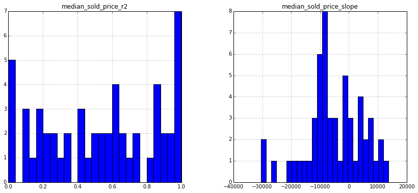

```python
median_saleprice, median_saleprice_adj = calculateSlope(by_subdivision, 'Median Sold Price')

median_saleprice[['median_sold_price_r2', 'median_sold_price_slope']].hist(bins=25, figsize=[14,6])
```

```python
print "The best fit:"
median_saleprice[median_saleprice.median_sold_price_r2 == median_saleprice.median_sold_price_r2.max()]
```

```
The best fit:
```

| Subdiv | median_sold_price_slope | median_sold_price_r2 | median_sold_price_min | median_sold_price_max | sales_count |
| --- | --- | --- | --- | --- | --- |
| Persimmon Park Pl | -25725 | 0.9974 | 47550 | 99000 | 21 |

1 rows × 5 columns

```python
print "The Worst fit:"
median_saleprice[median_saleprice.median_sold_price_r2 == median_saleprice.median_sold_price_r2.min()]
```

```
The Worst fit:
```

| Subdiv | median_sold_price_slope | median_sold_price_r2 | median_sold_price_min | median_sold_price_max | sales_count |
| --- | --- | --- | --- | --- | --- |
| Willowwood | -156.785714 | 0.000687 | 245000 | 262100 | 27 |

1 rows × 5 columns

### The top and bottom 5 for median saleprice

```python
print "TOP 5:"
median_saleprice.sort(['median_sold_price_slope'], ascending=False).head(5)
```

```
TOP 5:
```

| Subdiv | median_sold_price_slope | median_sold_price_r2 | median_sold_price_min | median_sold_price_max | sales_count |
| --- | --- | --- | --- | --- | --- |
| Edgehill Acres | 13725 | 0.338597 | 85500 | 132450 | 19 |
| Foxhall | 10825 | 0.712304 | 195000 | 232250 | 28 |
| Dover | 10350 | 0.868531 | 115000 | 150000 | 63 |
| Twin Willows | 8599 | 0.963497 | 195000 | 212198 | 20 |
| Bicentennial Vil | 7820 | 0.216181 | 146500 | 198000 | 30 |

5 rows × 5 columns

```python
print "TOP 5 (adjusted for R-squared)"
median_saleprice_adj.sort(['median_sold_price_slope'], ascending=False).head(5)
```

```
TOP 5 (adjusted for R-squared)
```

| Subdiv | median_sold_price_slope | median_sold_price_r2 | median_sold_price_min | median_sold_price_max | sales_count |
| --- | --- | --- | --- | --- | --- |
| Foxhall | 10825 | 0.712304 | 195000 | 232250 | 28 |
| Dover | 10350 | 0.868531 | 115000 | 150000 | 63 |
| Twin Willows | 8599 | 0.963497 | 195000 | 212198 | 20 |
| Towne Point | 7550 | 0.912478 | 103400 | 118500 | 21 |
| Heritage Trace | 3827 | 0.615299 | 257500 | 272250 | 26 |

5 rows × 5 columns

```python
print "BOTTOM 5:"
median_saleprice.sort(['median_sold_price_slope']).head(5)
```

```
BOTTOM 5:
```

| Subdiv | median_sold_price_slope | median_sold_price_r2 | median_sold_price_min | median_sold_price_max | sales_count |
| --- | --- | --- | --- | --- | --- |
| Spring Meadow | -30405.3 | 0.949058 | 249970 | 345619 | 55 |
| Laureltowne | -30400.0 | 0.637561 | 234900 | 305000 | 25 |
| Persimmon Park Pl | -25725.0 | 0.997400 | 47550 | 99000 | 21 |
| Cannon Mills | -21450.0 | 0.967586 | 122000 | 164900 | 20 |
| Village Of Westove | -18100.0 | 0.854263 | 109500 | 165000 | 62 |

5 rows × 5 columns

```python
print "BOTTOM 5 (adjusted for better R-squared):"
median_saleprice_adj.sort(['median_sold_price_slope']).head(5)
```

```
BOTTOM 5 (adjusted for better R-squared):
```

| Subdiv | median_sold_price_slope | median_sold_price_r2 | median_sold_price_min | median_sold_price_max | sales_count |
| --- | --- | --- | --- | --- | --- |
| Spring Meadow | -30405.3 | 0.949058 | 249970 | 345619 | 55 |
| Laureltowne | -30400.0 | 0.637561 | 234900 | 305000 | 25 |
| Persimmon Park Pl | -25725.0 | 0.997400 | 47550 | 99000 | 21 |
| Cannon Mills | -21450.0 | 0.967586 | 122000 | 164900 | 20 |
| Village Of Westove | -18100.0 | 0.854263 | 109500 | 165000 | 62 |

5 rows × 5 columns

### Close look at the top and bottom subdivisions by change in median saleprice

#### The top subdivisions (both normal and R2 adjusted)

```python
df[df.index == median_saleprice[median_saleprice.median_sold_price_slope == median_saleprice.median_sold_price_slope.max()].index]
```

| Subdiv | Year | Sales | Median Sold Price | Avg.SP | Median DOM | Avg.DOM | Median.SP.OLP | Median.SP.LP |
| --- | --- | --- | --- | --- | --- | --- | --- | --- |
| Edgehill Acres | 2011 | 5 | 105000 | 102980 | 144.0 | 230.40 | 0.724138 | 0.932203 |
| Edgehill Acres | 2012 | 6 | 85500 | 84050 | 67.5 | 100.00 | 0.862148 | 0.976190 |
| Edgehill Acres | 2013 | 8 | 132450 | 131100 | 57.5 | 118.25 | 0.952414 | 0.984882 |

3 rows × 8 columns

```python
df[df.index == median_saleprice[median_saleprice.median_sold_price_slope == median_saleprice_adj.median_sold_price_slope.max()].index]
```

| Subdiv | Year | Sales | Median Sold Price | Avg.SP | Median DOM | Avg.DOM | Median.SP.OLP | Median.SP.LP |
| --- | --- | --- | --- | --- | --- | --- | --- | --- |
| Foxhall | 2010 | 5 | 200000 | 222080.0000 | 46.0 | 78.200000 | 0.928903 | 0.953237 |
| Foxhall | 2011 | 7 | 195000 | 249714.2857 | 56.0 | 70.000000 | 0.890411 | 0.966989 |
| Foxhall | 2012 | 6 | 206500 | 197333.3333 | 77.0 | 99.166667 | 0.902686 | 0.983837 |
| Foxhall | 2013 | 10 | 232250 | 228890.0000 | 86.5 | 103.300000 | 0.944869 | 0.997387 |

4 rows × 8 columns

#### The bottom subdivisions (both normal and r-squared adjusted)

```python
df[df.index == median_saleprice[median_saleprice.median_sold_price_slope == median_saleprice.median_sold_price_slope.min()].index]
```

| Subdiv | Year | Sales | Median Sold Price | Avg.SP | Median DOM | Avg.DOM | Median.SP.OLP | Median.SP.LP |
| --- | --- | --- | --- | --- | --- | --- | --- | --- |
| Spring Meadow | 2010 | 11 | 345619 | 330140.4545 | 114.0 | 155.727273 | 1 | 1 |
| Spring Meadow | 2011 | 9 | 294106 | 312637.5556 | 298.0 | 353.222222 | 1 | 1 |
| Spring Meadow | 2012 | 16 | 277000 | 270628.3125 | 190.5 | 176.687500 | 1 | 1 |
| Spring Meadow | 2013 | 19 | 249970 | 252852.3684 | 172.0 | 182.736842 | 1 | 1 |

4 rows × 8 columns

```python
df[df.index == median_saleprice[median_saleprice.median_sold_price_slope == median_saleprice_adj.median_sold_price_slope.min()].index]
```

| Subdiv | Year | Sales | Median Sold Price | Avg.SP | Median DOM | Avg.DOM | Median.SP.OLP | Median.SP.LP |
| --- | --- | --- | --- | --- | --- | --- | --- | --- |
| Spring Meadow | 2010 | 11 | 345619 | 330140.4545 | 114.0 | 155.727273 | 1 | 1 |
| Spring Meadow | 2011 | 9 | 294106 | 312637.5556 | 298.0 | 353.222222 | 1 | 1 |
| Spring Meadow | 2012 | 16 | 277000 | 270628.3125 | 190.5 | 176.687500 | 1 | 1 |
| Spring Meadow | 2013 | 19 | 249970 | 252852.3684 | 172.0 | 182.736842 | 1 | 1 |

4 rows × 8 columns

# 3. Where can a seller get the best deal in terms of sale price / original listing price?

Back to top

```
array([[<matplotlib.axes.AxesSubplot object at 0x119beb450>,
        <matplotlib.axes.AxesSubplot object at 0x119dcb2d0>]], dtype=object)
```

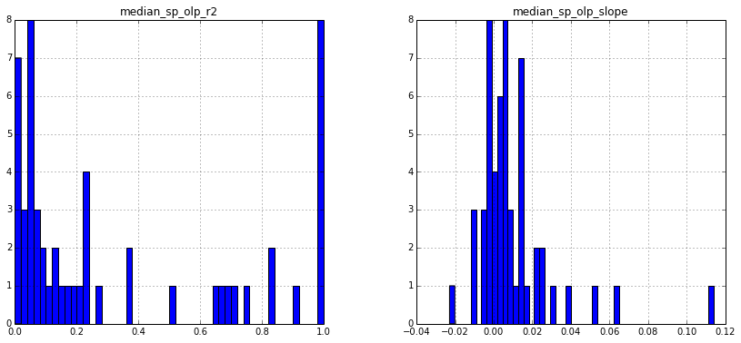

```python
lp, lp_adj = calculateSlope(by_subdivision, 'Median.SP.OLP')

lp[['median_sp_olp_r2', 'median_sp_olp_slope']].hist(bins=50, figsize=[14,6])
```

```python
print "The best fit:"
lp[lp.median_sp_olp_r2 == lp.median_sp_olp_r2.max()]
```

```
The best fit:
```

| Subdiv | median_sp_olp_slope | median_sp_olp_r2 | median_sp_olp_min | median_sp_olp_max | sales_count |
| --- | --- | --- | --- | --- | --- |
| Riverview Estates | 0.002294 | 0.999198 | 0.937852 | 0.94244 | 19 |

1 rows × 5 columns

```python
print "The Worst fit:"
lp[lp.median_sp_olp_r2 == lp.median_sp_olp_r2.min()]
```

```
The Worst fit:
```

| Subdiv | median_sp_olp_slope | median_sp_olp_r2 | median_sp_olp_min | median_sp_olp_max | sales_count |
| --- | --- | --- | --- | --- | --- |
| Sandy Hill | 0 | 0 | 1 | 1 | 31 |
| Spring Meadow | 0 | 0 | 1 | 1 | 55 |

2 rows × 5 columns

### The top and bottom 5 for sp/olp

```python
print "TOP 5:"
lp.sort(['median_sp_olp_slope'], ascending=False).head(5)
```

```
TOP 5:
```

| Subdiv | median_sp_olp_slope | median_sp_olp_r2 | median_sp_olp_min | median_sp_olp_max | sales_count |
| --- | --- | --- | --- | --- | --- |
| Edgehill Acres | 0.114138 | 0.985628 | 0.724138 | 0.952414 | 19 |
| Stoney Creek | 0.064380 | 0.997877 | 0.740741 | 0.935596 | 20 |
| Brenford Woods | 0.053560 | 0.989011 | 0.892889 | 1.000009 | 21 |
| Rodney Vil | 0.037616 | 0.998525 | 0.826763 | 0.938776 | 37 |
| Towne Point | 0.030787 | 0.998953 | 0.925926 | 0.987500 | 21 |

5 rows × 5 columns

```python
print "TOP 5 (adjusted for better r-squared):"
lp_adj.sort(['median_sp_olp_slope'], ascending=False).head(5)
```

```
TOP 5 (adjusted for better r-squared):
```

| Subdiv | median_sp_olp_slope | median_sp_olp_r2 | median_sp_olp_min | median_sp_olp_max | sales_count |
| --- | --- | --- | --- | --- | --- |
| Edgehill Acres | 0.114138 | 0.985628 | 0.724138 | 0.952414 | 19 |
| Stoney Creek | 0.064380 | 0.997877 | 0.740741 | 0.935596 | 20 |
| Brenford Woods | 0.053560 | 0.989011 | 0.892889 | 1.000009 | 21 |
| Rodney Vil | 0.037616 | 0.998525 | 0.826763 | 0.938776 | 37 |
| Towne Point | 0.030787 | 0.998953 | 0.925926 | 0.987500 | 21 |

5 rows × 5 columns

```python
print "BOTTOM 5:"
lp.sort(['median_sp_olp_slope']).head(5)
```

```
BOTTOM 5:
```

| Subdiv | median_sp_olp_slope | median_sp_olp_r2 | median_sp_olp_min | median_sp_olp_max | sales_count |
| --- | --- | --- | --- | --- | --- |
| Wynsome Knoll | -0.022862 | 0.363995 | 0.981859 | 1.057063 | 22 |
| The Greens Of Dove | -0.010423 | 0.199224 | 0.887302 | 0.959959 | 32 |
| The Hamlet | -0.010100 | 0.046254 | 0.779510 | 0.905624 | 27 |
| Emerald Pointe | -0.009323 | 0.261620 | 0.979918 | 1.036709 | 36 |
| Pinehurst Village | -0.005657 | 0.508423 | 1.006278 | 1.031111 | 55 |

5 rows × 5 columns

```python
print "BOTTOM 5 (adjusted for better r-squared):"
lp_adj.sort(['median_sp_olp_slope']).head(5)
```

```
BOTTOM 5 (adjusted for better r-squared):
```

| Subdiv | median_sp_olp_slope | median_sp_olp_r2 | median_sp_olp_min | median_sp_olp_max | sales_count |
| --- | --- | --- | --- | --- | --- |
| Pinehurst Village | -0.005657 | 0.508423 | 1.006278 | 1.031111 | 55 |
| Linkside | -0.003336 | 0.750000 | 1.000000 | 1.006671 | 59 |
| Riverview Estates | 0.002294 | 0.999198 | 0.937852 | 0.942440 | 19 |
| Heritage Trace | 0.006487 | 0.980493 | 0.903571 | 0.922140 | 26 |
| Stonegate | 0.007015 | 0.830888 | 0.948470 | 0.962500 | 21 |

5 rows × 5 columns

### Close look at the top and bottom subdivisions by sp/olp

#### Top subdivisions

```python
df[df.index == lp[lp.median_sp_olp_slope == lp.median_sp_olp_slope.max()].index]
```

| Subdiv | Year | Sales | Median Sold Price | Avg.SP | Median DOM | Avg.DOM | Median.SP.OLP | Median.SP.LP |
| --- | --- | --- | --- | --- | --- | --- | --- | --- |
| Edgehill Acres | 2011 | 5 | 105000 | 102980 | 144.0 | 230.40 | 0.724138 | 0.932203 |
| Edgehill Acres | 2012 | 6 | 85500 | 84050 | 67.5 | 100.00 | 0.862148 | 0.976190 |
| Edgehill Acres | 2013 | 8 | 132450 | 131100 | 57.5 | 118.25 | 0.952414 | 0.984882 |

3 rows × 8 columns

```python
df[df.index == lp[lp.median_sp_olp_slope == lp_adj.median_sp_olp_slope.max()].index]
```

| Subdiv | Year | Sales | Median Sold Price | Avg.SP | Median DOM | Avg.DOM | Median.SP.OLP | Median.SP.LP |
| --- | --- | --- | --- | --- | --- | --- | --- | --- |
| Edgehill Acres | 2011 | 5 | 105000 | 102980 | 144.0 | 230.40 | 0.724138 | 0.932203 |
| Edgehill Acres | 2012 | 6 | 85500 | 84050 | 67.5 | 100.00 | 0.862148 | 0.976190 |
| Edgehill Acres | 2013 | 8 | 132450 | 131100 | 57.5 | 118.25 | 0.952414 | 0.984882 |

3 rows × 8 columns

#### The bottom subdivisions

```python
df[df.index == lp[lp.median_sp_olp_slope == lp.median_sp_olp_slope.min()].index]
```

| Subdiv | Year | Sales | Median Sold Price | Avg.SP | Median DOM | Avg.DOM | Median.SP.OLP | Median.SP.LP |
| --- | --- | --- | --- | --- | --- | --- | --- | --- |
| Wynsome Knoll | 2011 | 9 | 190000.0 | 191672.000 | 40.0 | 40.666667 | 1.027582 | 1.027582 |
| Wynsome Knoll | 2012 | 8 | 190874.5 | 189867.875 | 68.5 | 88.625000 | 1.057063 | 1.046610 |
| Wynsome Knoll | 2013 | 5 | 186455.0 | 189305.600 | 156.0 | 330.600000 | 0.981859 | 1.035861 |

3 rows × 8 columns

### Throwing it all together for output to csv

```python
# Combine all of our stats into a single dataframe.
merge_out = pd.merge(
    left=median_dom[['sales_count','median_dom_slope', 'median_dom_r2', 'median_dom_min', 'median_dom_max']],
    right=median_saleprice[['median_sold_price_slope', 'median_sold_price_r2', 'median_sold_price_min', 'median_sold_price_max']],
    left_index=True,
    right_index=True)
merge_out = pd.merge(
    left=merge_out,
    right=lp[['median_sp_olp_slope', 'median_sp_olp_r2', 'median_sp_olp_min', 'median_sp_olp_max']],
    left_index=True,
    right_index=True)

# Add the rankings for each.
merge_out['dom_slope_rank'] = merge_out['median_dom_slope'].rank(ascending=True)
merge_out['median_price_rank'] = merge_out['median_sold_price_slope'].rank(ascending=False)
merge_out['sp_olp_rank'] = merge_out['median_sp_olp_slope'].rank(ascending=False)
merge_out['average_rank'] = merge_out[['dom_slope_rank', 'median_price_rank', 'sp_olp_rank']].mean(axis=1)
print "The Top Ten"
print merge_out.sort('average_rank')[['average_rank']].head(10)


merge_out.sort('average_rank').to_csv('data_out_kco.txt', sep='\t')
```

```
The Top Ten
                   average_rank
Subdiv
Edgehill Acres         3.333333
Brenford Woods         3.666667
Stoney Creek           4.333333
Towne Point            4.333333
Dover                 10.000000
Rodney Vil            11.333333
Wynn Wood             15.333333
Chimney Hill          17.333333
Crossgates            19.333333
Greens At Wyoming     19.500000

[10 rows x 1 columns]
```

Click here to download the final data.